# ELO Calculations

Assignment 5B: Code Base

Author

Jocelyn Slater

## Introduction

Using the player’s pre-ratings and expected scores for each round match up (Project 1), we calculate the difference between expected score and actual score to evaluate under and over performance. The expected score $E_A$ is calcualted using the following formula:

$$E_A = \frac{1}{1 + 10^{(R_B - R_A) / 400}}$$
$E_A =$ expected score

$R_{A} =$ current rating

$R_{B} =$ opponent’s rating

$400 =$ a scaling factor

The tournament data is imported using the same code as used in Project 1. New code begins after the dashed divider.

## Data Import

Import the crosstable as plain text are remove lines that are just the separator rows and headers, just leaving lines with real content.

```r
url <- "https://raw.githubusercontent.com/jocslater-code/DATA607/refs/heads/main/Project1/tournamentinfo.txt"
raw_txt <- suppressWarnings(readLines(url))
# Remove the separator lines and header
content_lines <- raw_txt[!str_detect(raw_txt, "^\\s*---")]
content_lines <- content_lines[3:length(content_lines)]
```

## Parse Data

Each player has data that spans two lines, so we need to combine the information from those lines into one combined string, and then parse that string by the | delimiter and white space. Then we place the matrix of parsed strings into a dataframe.

```r
# Create a grouping variable for line combination
player_groups <- rep(1:(length(content_lines) / 2), each = 2)

# Combine the two lines for each player into a single string
combined_records <- tapply(content_lines, player_groups, paste0, collapse = " | ")

# Split by '|' whitespace
split_matrix <- str_split(combined_records, "\\|")
cleaned_data <- lapply(split_matrix, function(row) str_trim(row))

# Convert to a data frame
df_all <- as.data.frame(do.call(rbind, cleaned_data), stringsAsFactors = FALSE)
```

## Tidy Dataframe

To only work with necessary data, we create a tidy data frame with just subselected columns, relabeled for clarity.

```r
# Sub-select the columns
df_tidy <- select(df_all, V1, V2, V3, V4, V5, V6, V7, V8, V9,V10, V12, V13)

# Rename the columns
colnames(df_tidy) <- c(
  "num", "player_name", "total_pts", "R1", "R2", "R3", "R4", "R5",
  "R6", "R7", "state", "rating_str"
)
```

## Parse Data and Calculate Opponent Information

We create a new column with each player’s pre-tournament rating,

```r
# Parse the rating string to just get the pre-tournament rating
# Extract the digits inside the capture group after 'R:'
df_tidy$pre_rating <- str_match(df_tidy$rating_str, "R:\\s*(\\d+)")[, 2]
# \s is for spaces
# (\\d+) grabs all of the numbers up until the next non-digit character like a P, space, or ->

df_tidy$pre_rating <- as.numeric(df_tidy$pre_rating)
```

Then we extracted the opponent number for each round and saved them as seven new columns. Opponent numbers were subbed for NA in cases where the game was anything else then a win, lose, or draw since, for the purposes of our exercize, those were the only games that contributed.

```r
# If the game is not won, lost, or draw, fill with NA
df_tidy <- df_tidy %>%
  mutate(across(starts_with("R", ignore.case = FALSE), ~ ifelse(str_detect(., "[WLD]"), ., NA)))

# Create new column that just has the opponent number for each round played
# There is a better way to do this with * or \\d
df_tidy <- df_tidy %>%
  mutate(across(starts_with("R1", ignore.case = FALSE),
                ~ as.numeric(str_extract(., "\\d+")),
                .names = "{.col}_opp_name"))
df_tidy <- df_tidy %>%
  mutate(across(starts_with("R2", ignore.case = FALSE),
                ~ as.numeric(str_extract(., "\\d+")),
                .names = "{.col}_opp_name"))
df_tidy <- df_tidy %>%
  mutate(across(starts_with("R3", ignore.case = FALSE),
                ~ as.numeric(str_extract(., "\\d+")),
                .names = "{.col}_opp_name"))
df_tidy <- df_tidy %>%
  mutate(across(starts_with("R4", ignore.case = FALSE),
                ~ as.numeric(str_extract(., "\\d+")),
                .names = "{.col}_opp_name"))
df_tidy <- df_tidy %>%
  mutate(across(starts_with("R5", ignore.case = FALSE),
                ~ as.numeric(str_extract(., "\\d+")),
                .names = "{.col}_opp_name"))
df_tidy <- df_tidy %>%
  mutate(across(starts_with("R6", ignore.case = FALSE),
                ~ as.numeric(str_extract(., "\\d+")),
                .names = "{.col}_opp_name"))
df_tidy <- df_tidy %>%
  mutate(across(starts_with("R7", ignore.case = FALSE),
                ~ as.numeric(str_extract(., "\\d+")),
                .names = "{.col}_opp_name"))
```

Once we had an opponent’s name for each round, we then pulled the corresponding pre-rating and saved it as a numeric in another column

```r
# Make new columns for opponent pre-ratings
opp_cols <- paste0("R", 1:7, "_opp_name")

# Loop through each opponent column and pull the matching pre_rating
for (col in opp_cols) {
  new_col <- paste0(col, "_score")
  df_tidy[[new_col]] <- df_tidy$pre_rating[df_tidy[[col]]]
}
```

## Elo Calculation

```r
# Make new dataframe with only pertinent Elo columns and rename them because this getting long...
df_Elo <- select(df_tidy, num, player_name, pre_rating, total_pts, R1_opp_name_score, R2_opp_name_score, R3_opp_name_score, R4_opp_name_score, R5_opp_name_score, R6_opp_name_score, R7_opp_name_score)
colnames(df_Elo) <- c("num", "player_name", "pre_rating", "total_pts", "R1_opp_rating", "R2_opp_rating", "R3_opp_rating", "R4_opp_rating", "R5_opp_rating", "R6_opp_rating", "R7_opp_rating")

# Calculate expected score
df_Elo <- df_Elo %>%
  mutate(
    across(
      starts_with("R") & ends_with("_opp_rating"),
      ~ 1 / (1 + 10^((.x - pre_rating) / 400)),
      .names = "{.col}_expected"
    )
  )
# Rename columns again
colnames(df_Elo) <- c("num", "player_name", "pre_rating", "total_pts", "R1_opp_rating", "R2_opp_rating", "R3_opp_rating", "R4_opp_rating", "R5_opp_rating", "R6_opp_rating", "R7_opp_rating", "R1_EA","R2_EA", "R3_EA", "R4_EA", "R5_EA", "R6_EA", "R7_EA")
```

Once we have the expected score for each round, we can sum these up to get the total expected score, and compare this with the actual score in a new column.

```r
# Add new column with the sum of all of the expected scores so we can compare this to the actual score
expected_cols <- grep("_EA", names(df_Elo), value = TRUE)

# Compute total expected score from the rounds for each player
df_Elo$total_EA <- rowSums(df_Elo[, expected_cols], na.rm = TRUE)

df_Elo$diff_EA <- as.numeric(df_Elo$total_pts)-df_Elo$total_EA
```

## Expected Score Analysis

Now that we have the expected scores, actual, and the differences, we can analyze player performance. Specifically, we are looking for the five players who underperformed (largest negative difference) and who overperformed (largest positive difference).

```r
# Count how many players under/overperformed
df_Elo %>%
  filter(!is.na(diff_EA)) %>%
  summarise(
    Positive = sum(diff_EA > 0),
    Negative = sum(diff_EA < 0),
    Zero     = sum(diff_EA == 0)
  )
```

```
  Positive Negative Zero
1       36       28    0
```

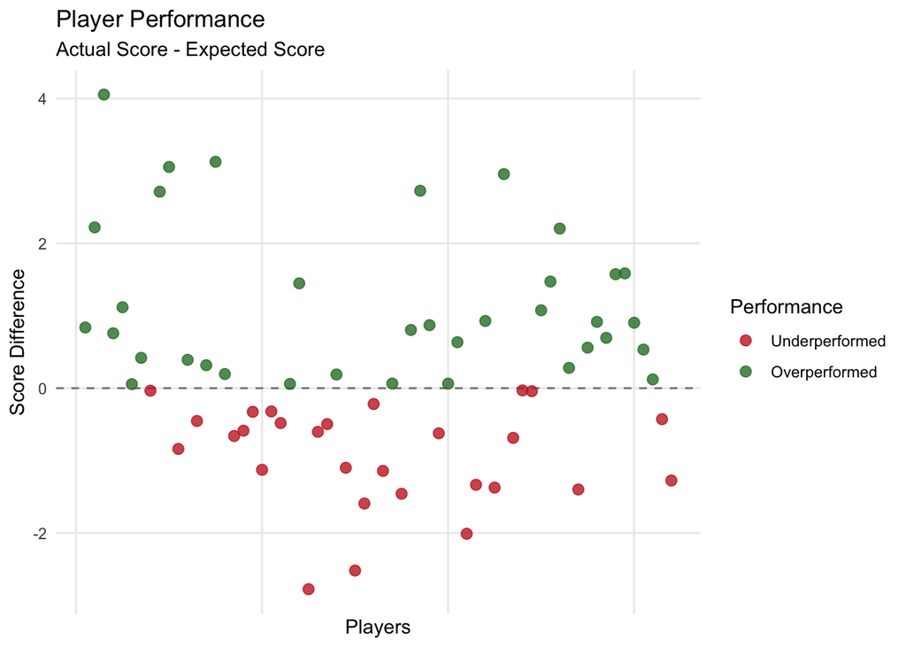

```r
# Scatter plot of all performances
df_Elo %>%
  filter(!is.na(diff_EA)) %>%
  mutate(player_index = row_number()) %>%
  ggplot(aes(x = player_index, y = diff_EA)) +
  geom_hline(yintercept = 0, linetype = "dashed", color = "gray50") +
  geom_point(aes(color = diff_EA > 0), size = 2.5, alpha = 0.8) +
  scale_color_manual(
    values = c("TRUE" = "#2e7d32", "FALSE" = "#c62828"),
    labels = c("TRUE" = "Overperformed", "FALSE" = "Underperformed"),
    name = "Performance"
  ) +
  labs(
    title = "Player Performance",
    subtitle = "Actual Score - Expected Score",
    x = "Players",
    y = "Score Difference"
  ) +
  theme_minimal() +
  theme(
    axis.text.x = element_blank(),  # Hides x-axis tick labels (names/numbers)
    axis.ticks.x = element_blank(), # Hides x-axis ticks
    panel.grid.minor = element_blank()
  )
```

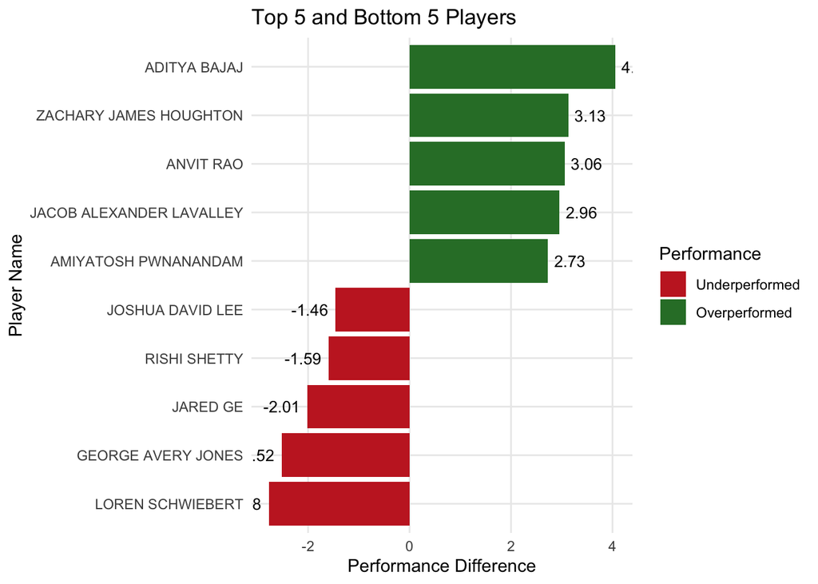

```r
# Get top 5 largest and top 5 smallest in new dataframe
top_bottom_df <- df_Elo %>%
  filter(!is.na(diff_EA)) %>%
  slice_max(order_by = diff_EA, n = 5) %>%
  bind_rows(
    df_Elo %>%
      filter(!is.na(diff_EA)) %>%
      slice_min(order_by = diff_EA, n = 5)
  )
top_bottom_df <- select(top_bottom_df, player_name, diff_EA)
top_bottom_df <- arrange(top_bottom_df, diff_EA)

# Plot this in a sideways bar chart
ggplot(top_bottom_df, aes(x = reorder(player_name, diff_EA), y = diff_EA, fill = diff_EA > 0)) +
  geom_col() +
  geom_text(
    aes(label = round(diff_EA, 2)),
    hjust = ifelse(top_bottom_df$diff_EA >= 0, -0.2, 1.2),
    size = 3.5
  ) +
  coord_flip() +
  scale_fill_manual(
    values = c("TRUE" = "#2e7d32", "FALSE" = "#c62828"),
    labels = c("TRUE" = "Overperformed", "FALSE" = "Underperformed"),
    name = "Performance"
  ) +
  labs(
    title = "Top 5 and Bottom 5 Players",
    x = "Player Name",
    y = "Performance Difference"
  ) +
  theme_minimal() +
  theme(panel.grid.minor = element_blank())
```

## Discussion and Next Steps

It seems that for this chess tournament, the majority of players had a good day - 56% of them overperformed, exceeding their expected scores. Aditya Baiaj had the best day of all though, overperforming by a full 4 points!

Further work could be to repeat this analysis with other tournament data to observe trends among other player groups. We could explore if certain demographics for players or factors of the day (time games are played, weather, location) impacts performance. I would also be currious to explore the cumulative effect of each game; if a player wins/loses the prior game, how does that statistically effect the following games?

## Citations

Elo Chess Rating Calculator. (2026). *Expected score in Elo chess ratings*. https://elochessratingcalculator.com/learn/elo/expected-score/

Google DeepMind. (2026). Gemini 3.6 Flash [Large language model]. https://gemini.google.com. Accessed Sept 29, 2026. Transcript available in Github as Assignment5B_Gemini_Transcript.pdf